# Classification supervisée : fiche TP1, corrigé

Vincent Vandewalle, Cristian Preda

```r
knitr::opts_chunk$set(echo = TRUE, error = TRUE)
```

# Reprise des exemples du cours

Lancer les commandes suivantes pour retrouver les résultats des exercices de la première séance de cours.

## Test du Chi-deux

```r
V3V1<-matrix(c(30,20,30,20,10,15,10,15),4,2,byrow=TRUE)
V3V1
```

```
##      [,1] [,2]
## [1,]   30   20
## [2,]   30   20
## [3,]   10   15
## [4,]   10   15
```

```r
chi2 = chisq.test(V3V1)
str(chi2)
```

```
## List of 9
##  $ statistic: Named num 5.36
##   ..- attr(*, "names")= chr "X-squared"
##  $ parameter: Named int 3
##   ..- attr(*, "names")= chr "df"
##  $ p.value  : num 0.147
##  $ method   : chr "Pearson's Chi-squared test"
##  $ data.name: chr "V3V1"
##  $ observed : num [1:4, 1:2] 30 30 10 10 20 20 15 15
##  $ expected : num [1:4, 1:2] 26.7 26.7 13.3 13.3 23.3 ...
##  $ residuals: num [1:4, 1:2] 0.645 0.645 -0.913 -0.913 -0.69 ...
##  $ stdres   : num [1:4, 1:2] 1.16 1.16 -1.46 -1.46 -1.16 ...
##  - attr(*, "class")= chr "htest"
```

```r
chi2
```

```
##
##  Pearson's Chi-squared test
##
## data:  V3V1
## X-squared = 5.3571, df = 3, p-value = 0.1474
```

```r
1-pchisq(5.3571,3)
```

```
## [1] 0.1474399
```

```r
sum(chi2$residuals^2)
```

```
## [1] 5.357143
```

1. Commenter code et résultats : ici on réalise un test du Chi-deux d’indépendance, on ne rejetterai pas l’hypothèse d’indépendance au risque $\alpha = 0,05$.

## Test de Fisher

```r
x <- c(4,5,7,8,9,2,3,4,6,7,8)
y <- c(rep(0,5),rep(1,6))
cbind(x,y)
```

```
##       x y
##  [1,] 4 0
##  [2,] 5 0
##  [3,] 7 0
##  [4,] 8 0
##  [5,] 9 0
##  [6,] 2 1
##  [7,] 3 1
##  [8,] 4 1
##  [9,] 6 1
## [10,] 7 1
## [11,] 8 1
```

```r
lm(x~factor(y))
```

```
##
## Call:
## lm(formula = x ~ factor(y))
##
## Coefficients:
## (Intercept)   factor(y)1
##         6.6         -1.6
```

```r
factor(y)
```

```
##  [1] 0 0 0 0 0 1 1 1 1 1 1
## Levels: 0 1
```

```r
anova(lm(x~y))
```

|  | Df | Sum Sq | Mean Sq | F value | Pr(>F) |
| --- | --- | --- | --- | --- | --- |
| y | 1 | 6.981818 | 6.981818 | 1.390185 | 0.2686035 |
| Residuals | 9 | 45.200000 | 5.022222 | NA | NA |

```r
SCF <- (mean(x[1:5])-mean(x))^2*5+(mean(x[6:11])-mean(x))^2*6
SCR <- sum(c((x[1:5]-mean(x[1:5]))^2,(x[6:11]-mean(x[6:11]))^2))
Fstat <- (SCF/1)/(SCR/9)
pval <- pf(Fstat,1,9,lower.tail=FALSE)
pval
```

```
## [1] 0.2686035
```

```r
Rsq <- SCF/(SCF+SCR)
Rsq
```

```
## [1] 0.1337979
```

```r
c(SCF,SCR,Fstat,pval,Rsq)
```

```
## [1]  6.9818182 45.2000000  1.3901850  0.2686035  0.1337979
```

```r
summary(lm(x~y))$r.squared
```

```
## [1] 0.1337979
```

```r
pchisq(6.585^2,df = 1, lower.tail = FALSE)
```

```
## [1] 4.548854e-11
```

2. Commenter code et résultats : Ici on a réalisé un test de l’ANOVA, sous $H_0$ la statistique de test suit une loi de Fisher a $K-1$, $n-K$ degré de liberté, avec $K$ le nombre de classes et $n$ le nombre de données. Ici la probabilité critique est de $0,2686$ donc la variable $y$ n’a pas d’effet significatif sur la variable $x$ au risque $\alpha = 0,05$.

**Attention** : en classification supervisée on veut prédire $y$ à partir de $x$ ! Mais le fait que la variance de $x$ soit bien expliquée par $y$ nous donne un bon indicateur du pouvoir prédictif $x$ sur $y$.

# Analyse préliminaire du jeu de données `iris`, ANOVA et MANOVA

## Analyse préliminaire du jeu de données `iris`

Dans cette partie on utilisera les données `iris`.

3. Faire `data("iris")` dans R.

```r
data("iris")
head(iris)
```

|  | Sepal.Length | Sepal.Width | Petal.Length | Petal.Width | Species |
| --- | --- | --- | --- | --- | --- |
| 1 | 5.1 | 3.5 | 1.4 | 0.2 | setosa |
| 2 | 4.9 | 3.0 | 1.4 | 0.2 | setosa |
| 3 | 4.7 | 3.2 | 1.3 | 0.2 | setosa |
| 4 | 4.6 | 3.1 | 1.5 | 0.2 | setosa |
| 5 | 5.0 | 3.6 | 1.4 | 0.2 | setosa |
| 6 | 5.4 | 3.9 | 1.7 | 0.4 | setosa |

4. Renommer les variables “Sepal.Length”, “Sepal.Width”, “Petal.Length”, “Petal.Width”,“Species” en “X1”, “X2”, “X3”, “X4”, “Y”.

```r
names(iris) <- c("X1","X2","X3","X4","Y")
```

5. Représenter graphiquement le lien entre X1 et Y :

```r
library(dplyr)
```

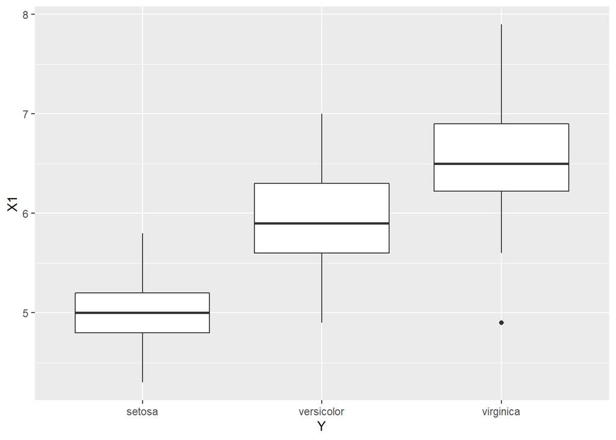

```r
library(ggplot2)
iris %>%
  ggplot(aes(x = Y, y = X1)) +
  geom_boxplot()
```

Puis faire de même pour les autres variables :

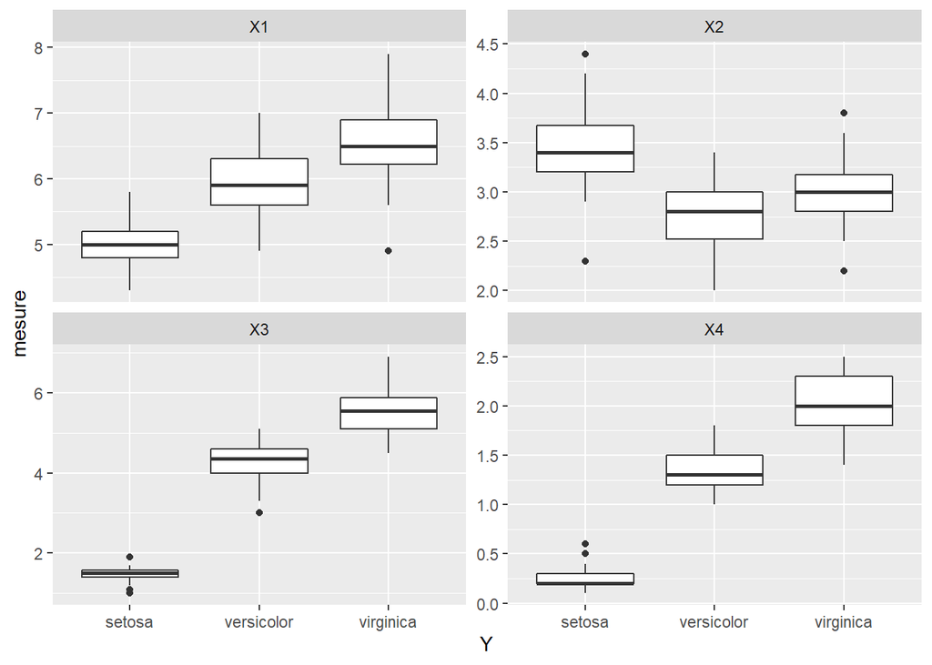

```r
library("tidyr")
iris %>%
  gather("variable","mesure",-Y) %>%
  ggplot(aes(x = Y, y = mesure)) +
  geom_boxplot() +
  facet_wrap(~ variable, scales = "free_y")
```

Commenter : On voit que les variable pour lesquelles les classes sont les mieux séparées sont les variable $X_3$ et $X_4$.

## ANOVA

Réaliser l’ANOVA de X1 en fonction de Y et obtenir le $R^2$ associé, faire de même pour les autres variables. A partir des p-values, indiquer si la variable Y a une influence sur l’ensemble des variables. Quelle est la variable la mieux expliquée par Y ?

Ajustement du modèle linéaire pour X1

```r
lm(X1 ~ Y, data = iris)
```

```
##
## Call:
## lm(formula = X1 ~ Y, data = iris)
##
## Coefficients:
## (Intercept)  Yversicolor   Yvirginica
##       5.006        0.930        1.582
```

```r
shapiro.test(iris$X1[iris$Y == "setosa"])
```

```
##
##  Shapiro-Wilk normality test
##
## data:  iris$X1[iris$Y == "setosa"]
## W = 0.9777, p-value = 0.4595
```

```r
# Test de normalité groupe par groupe :
by(data = iris$X1, INDICES = iris$Y, shapiro.test)
```

```
## iris$Y: setosa
##
##  Shapiro-Wilk normality test
##
## data:  dd[x, ]
## W = 0.9777, p-value = 0.4595
##
## ------------------------------------------------------------
## iris$Y: versicolor
##
##  Shapiro-Wilk normality test
##
## data:  dd[x, ]
## W = 0.97784, p-value = 0.4647
##
## ------------------------------------------------------------
## iris$Y: virginica
##
##  Shapiro-Wilk normality test
##
## data:  dd[x, ]
## W = 0.97118, p-value = 0.2583
```

```r
# Ici accepte l'hypothèse de normalité dans chacune des classes

# Test d'homogénité des variances :
bartlett.test(iris$X1, iris$Y)
```

```
##
##  Bartlett test of homogeneity of variances
##
## data:  iris$X1 and iris$Y
## Bartlett's K-squared = 16.006, df = 2, p-value = 0.0003345
```

```r
# p-value = 0.0003345
# On rejette l'homogénéité des variances
# Attention : conclusion du test de l'ANOVA possiblement erronnées

summary(lm(X1 ~ Y, data = iris)) # Résumé
```

```
##
## Call:
## lm(formula = X1 ~ Y, data = iris)
##
## Residuals:
##     Min      1Q  Median      3Q     Max
## -1.6880 -0.3285 -0.0060  0.3120  1.3120
##
## Coefficients:
##             Estimate Std. Error t value Pr(>|t|)
## (Intercept)   5.0060     0.0728  68.762  < 2e-16 ***
## Yversicolor   0.9300     0.1030   9.033 8.77e-16 ***
## Yvirginica    1.5820     0.1030  15.366  < 2e-16 ***
## ---
## Signif. codes:  0 '***' 0.001 '**' 0.01 '*' 0.05 '.' 0.1 ' ' 1
##
## Residual standard error: 0.5148 on 147 degrees of freedom
## Multiple R-squared:  0.6187, Adjusted R-squared:  0.6135
## F-statistic: 119.3 on 2 and 147 DF,  p-value: < 2.2e-16
```

```r
summary(lm(X1 ~ Y, data = iris))$r.squared
```

```
## [1] 0.6187057
```

Extension à chacune des variables

```r
sapply(names(iris)[-5],
       function(x) summary(lm(as.formula(paste(x,"~ Y")),
                              data = iris))$r.squared)
```

```
##        X1        X2        X3        X4
## 0.6187057 0.4007828 0.9413717 0.9288829
```

$$R^2_{X_4 / Y} = \frac{\mbox{Variance de }X_4 \mbox{ expliquée par } Y }{\mbox{Variance de }X_4} = 92,8\%$$

Calcul de l’ANOVA (calcul de la p-value du test)

```r
anova(lm(X1~Y,data=iris))
```

|  | Df | Sum Sq | Mean Sq | F value | Pr(>F) |
| --- | --- | --- | --- | --- | --- |
| Y | 2 | 63.21213 | 31.6060667 | 119.2645 | 1.669669e-31 |
| Residuals | 147 | 38.95620 | 0.2650082 | NA | NA |

```r
anova(lm(X1~Y,data=iris))$`Pr(>F)`
```

```
## [1] 1.669669e-31           NA
```

```r
anova(lm(X1~Y,data=iris))$`Pr(>F)`[1]
```

```
## [1] 1.669669e-31
```

Extension à chacune des variables

```r
sapply(names(iris)[-5],
       function(x) anova(lm(as.formula(paste(x,"~ Y")),
                            data = iris))$`Pr(>F)`[1])
```

```
##           X1           X2           X3           X4
## 1.669669e-31 4.492017e-17 2.856777e-91 4.169446e-85
```

7. Commentez ces résultats : la sous-espèce a-t’elle un effet significatif sur l’espérance de X1 ? de X2 ? de X3 ? de X4 ? Sur l’espérance de $X = \begin{pmatrix} X_1 \\ X_2 \\ X_3 \\ X_4 \end{pmatrix}$ ?

Oui la sous-espéce à un effet significatif sur chacune des variables explicatives.

Ici vous avez testé :
$$H_{0j} = \{ \mu_{1j} = \mu_{2j} = \mu_{3j} \} \mbox{ contre } H_{1j} = \{\exists i \neq i'| \mu_{ij} \neq \mu_{i'j} \},$$
pour $j \in \{1,2,3,4\}$, c’est-à-dire pour chacune des variables séparément.

Mais, ce que nous souhaitons tester ici est : y-a-t’il une différence entre groupes pour au moins une des variables ? :
$$H_{0} = \{ \mu_{1} = \mu_{2} = \mu_{3} \} \mbox{ contre } H_{1} = \{\exists j \in \{1,2,3,4\}, \exists i \neq i'| \mu_{ij} \neq \mu_{i'j} \}$$
avec $\mu_i = \begin{pmatrix} \mu_{i1} \\ \mu_{i2} \\ \mu_{i3} \\ \mu_{i4}\end{pmatrix}$.

Comment recoller les morceaux ???

Remarquons d’abord que :
$$H_0 = \cap_{j=1}^{4} H_{0j} = H_{01} \cap H_{02} \cap H_{03} \cap H_{04}$$

Ainsi $H_0$ est fausse du moment qu’au moins une des $H_{0j}$ est fausse. La question est alors quel est le risque de première espèce $\alpha_{global}$ de rejeter $H_0$ à tord quand on se donne un risque de première espèce $\alpha$ de rejeter $H_{0j}$ à tord pour $j \in \{1,2,3,4\}$ ? Et comment choisir $\alpha$ de manière à maintenir un risque global $\alpha_{global}$ ?

On note $p_j$ les probabilités critiques associées à chacune de $H_{0j}$. Sous $H_{0j}$ on sait que $p_j$ suit une loi uniforme sur $[0;1]$ ($p_j \sim U([0;1])$). En notant $A_j$ l’événement $H_{0j}$ est rejeté, $A_j = \{p_j \leq \alpha \}$.

$$P_{H_0}(\mbox{rejet de } H_0 \mbox{ à tord}) = P_{H_0}(\cup_{j=1}^{d} A_j) = P_{H_0}(\cup_{j=1}^{d}\{p_j \leq \alpha\})
\leq \sum_{j = 1}^{d}P_{H_{0j}}\left(p_j \leq \alpha\right) = d \times \alpha$$

Ainsi, si on veut s’assurer que $P_{H_0}(\mbox{rejet de } H_0 \mbox{ à tord}) \leq \alpha_{global}$, on peut choisir $\alpha = \frac{\alpha_{global}}{d}$. Il s’agit de la correction de **Bonferroni** (cette correction est plutôt frustre et on peu parfois lui préférer d’autres corrections comme l’utilisation du False Discovery Rate (FDR) qui vise à controler le pourcentage de faux positifs).

8. On se donne un risque de première espèce $\alpha_{global} = 0,05$, réaliser l’ajustement de Bonferroni. Rejettez-vous $H_0$ ?

```r
alpha_glo = 0.05
d = 4
alpha = alpha_glo/d
alpha
```

```
## [1] 0.0125
```

```r
pvalue = sapply(names(iris)[-5],
       function(x) anova(lm(as.formula(paste(x,"~ Y")),
                            data = iris))$`Pr(>F)`[1])
pvalue
```

```
##           X1           X2           X3           X4
## 1.669669e-31 4.492017e-17 2.856777e-91 4.169446e-85
```

```r
any(pvalue < alpha) # TRUE : moins une des
```

```
## [1] TRUE
```

```r
# p-valeurs est inférieure à 0,0125 donc on rejette H_0 au risque global alpha = 0,05 ! La distribution de X varie en fonction du groupe Y.
```

## MANOVA

Contrairement à la situation précédente on souhaite tester directement $H_0$ contre $H_1$, ce qui impose un modèle sur la distribution du vecteur $X$ sachant la classe $Y$ :

- $X | Y = k \sim \mathcal{N}_d(\mu_i;\Sigma_i)$ : Hypothèse de normalité sachant la classe
- $\Sigma_1 = \Sigma_2 = \cdots = \Sigma_K = \Sigma$ : Hypothèse d’homogénéité des variances

En utilisant la fonction `ggpairs` du package `GGally` on représente les corrélations deux à deux entre les différentes variables en fonction de la variable `Y` comme suit :

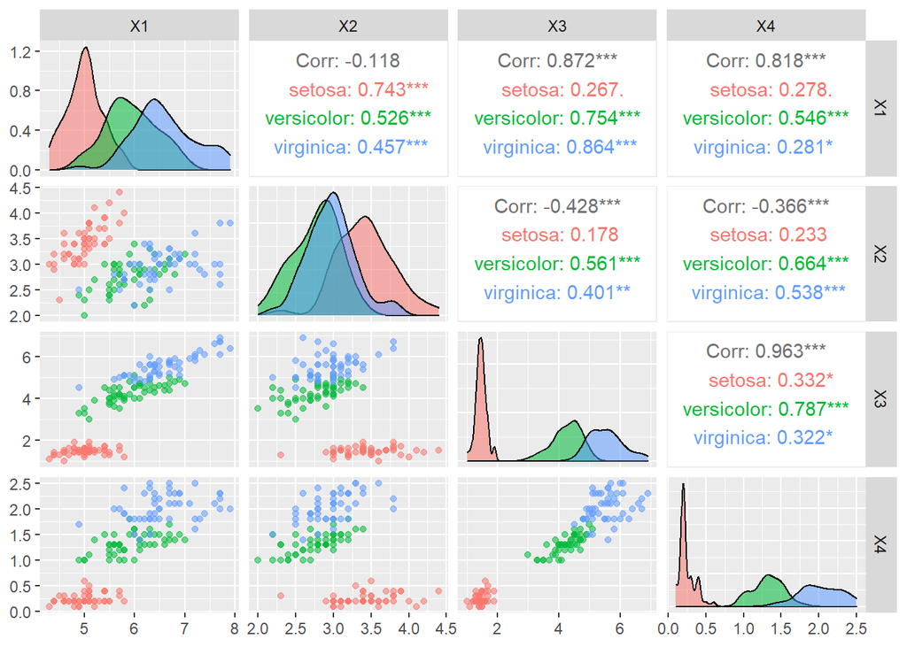

```r
library(GGally)
ggpairs(iris, columns = 1:4, aes(color = Y, alpha = 0.8))
```

9. Commenter le graphique obtenus, que dire des hypothèses de normalité et d’homogénéité des variances ?

Ici à l’allure du nuage de point on peut éventuellement admettre un normalité classe par classe, cependant l’hypothèse d’homogénéité des variance ne semble pas vérifiée (allure du nuage de point différente d’une classe à l’autre).

A l’aide de la fonction `mshapiro.test` de la librairie `mvnormtest` réaliser un test de normalité pour chacune des classes :

```r
# install.packages("mvnormtest")
library(mvnormtest)
mshapiro.test(as.matrix(t(iris[iris$Y=="versicolor",1:4])))
```

```
##
##  Shapiro-Wilk normality test
##
## data:  Z
## W = 0.93043, p-value = 0.005739
```

```r
mshapiro.test(as.matrix(t(iris[iris$Y=="setosa",1:4])))
```

```
##
##  Shapiro-Wilk normality test
##
## data:  Z
## W = 0.95878, p-value = 0.07906
```

```r
mshapiro.test(as.matrix(t(iris[iris$Y=="virginica",1:4])))
```

```
##
##  Shapiro-Wilk normality test
##
## data:  Z
## W = 0.93414, p-value = 0.007955
```

10. Commenter : Ici on rejetterai l’hypothèse de normalité, sauf pour la classe setosa

A l’aide de la fonction contenue dans le fichier on réalise le test d’égalité des matrices de variances-covariances.

```r
source("BoxMTest.R") # Fichier à récupérer sur moodle
BoxMTest(iris[,1:4],iris$Y)
```

```
## ------------------------------------------------
##  MBox Chi-sqr. df P
## ------------------------------------------------
##   146.6632   140.9430          20       0.0000
## ------------------------------------------------
## Covariance matrices are significantly different.
```

```
## $MBox
##   setosa
## 146.6632
##
## $ChiSq
##  setosa
## 140.943
##
## $df
## [1] 20
##
## $pValue
##       setosa
## 3.352034e-20
```

11. Commenter : Ici on rejette l’hypothèse d’homogénéité des variances. Par conséquent nous ne somme pas sous les conditions d’application du test de la MANOVA, on peut alors lui des versions non paramètriques ne reposant pas sur l’hypothèse de normalité, comme par exemple de le test de Kruskal-Wallis multivarié.

A l’aide de la fonction `manova` de R tester l’égalité des espérances des groupes : `manova(cbind(X1,X2,X3,X4) ~ Y, data = iris)`

```r
iris_manova = manova(cbind(X1,X2,X3,X4)~Y,data=iris)
```

Obtenir les résumés à partir de la fonction `summary` appliquée à l’objet précédent :

```r
summary(iris_manova) # compléter
```

```
##            Df Pillai approx F num Df den Df    Pr(>F)
## Y           2 1.1919   53.466      8    290 < 2.2e-16 ***
## Residuals 147
## ---
## Signif. codes:  0 '***' 0.001 '**' 0.01 '*' 0.05 '.' 0.1 ' ' 1
```

12. Commenter : Ici la statistique de test utilisée est la statistique de Pillai, une transformation appliquée à la statistique de test suit approximativement une loi de Fisher à $8$ et $290$ dgegrés de liberté. Ici on rejette $H_0$.
13. Aller voir dans l’aide de la fonction `summary.manova` pour modifier la statistique de test utilisée

```r
help("summary.manova")
```

```
## starting httpd help server ... done
```

```r
summary(iris_manova,"Pillai")
```

```
##            Df Pillai approx F num Df den Df    Pr(>F)
## Y           2 1.1919   53.466      8    290 < 2.2e-16 ***
## Residuals 147
## ---
## Signif. codes:  0 '***' 0.001 '**' 0.01 '*' 0.05 '.' 0.1 ' ' 1
```

```r
summary(iris_manova,"Wilks")
```

```
##            Df    Wilks approx F num Df den Df    Pr(>F)
## Y           2 0.023439   199.15      8    288 < 2.2e-16 ***
## Residuals 147
## ---
## Signif. codes:  0 '***' 0.001 '**' 0.01 '*' 0.05 '.' 0.1 ' ' 1
```

```r
summary(iris_manova,"Hotelling-Lawley")
```

```
##            Df Hotelling-Lawley approx F num Df den Df    Pr(>F)
## Y           2           32.477   580.53      8    286 < 2.2e-16 ***
## Residuals 147
## ---
## Signif. codes:  0 '***' 0.001 '**' 0.01 '*' 0.05 '.' 0.1 ' ' 1
```

```r
summary(iris_manova,"Roy")
```

```
##            Df    Roy approx F num Df den Df    Pr(>F)
## Y           2 32.192     1167      4    145 < 2.2e-16 ***
## Residuals 147
## ---
## Signif. codes:  0 '***' 0.001 '**' 0.01 '*' 0.05 '.' 0.1 ' ' 1
```

14. Commenter les résultats obtenus : Dans chacun des cas on rejette $H_0$.

Par la suite on va calculer les matrices $W$ et $B$ qui pourraient être utilisées pour récalculer les statistiques de test ci-dessus.

# Analyse factorielle discriminante (iris de Fisher)

## Calcul des matrices

```r
V = cov.wt(iris[,1:4],method = "ML")$cov
```

Attention on prendra garde de récupérer le bon élément de sortie de la fonction `cov.wt`, fonction qui ressort une liste contenant entre autres `cov`, `center`, …

On calcule les vecteurs des moyennes pour chaque groupe $\bar{X}_{i}$ en s’aidant de la fonction `by`, et en restructurant le résultat sous forme d’un tableau.

Constituez la matrice $G$ de centres des classes composée d’une colonne par variable et d’une ligne par sous-espèce (on rappelle que la fonction `t` permet de transposer un tableau)

```r
by(iris[,1:4],iris$Y, colMeans)
```

```
## iris$Y: setosa
##    X1    X2    X3    X4
## 5.006 3.428 1.462 0.246
## ------------------------------------------------------------
## iris$Y: versicolor
##    X1    X2    X3    X4
## 5.936 2.770 4.260 1.326
## ------------------------------------------------------------
## iris$Y: virginica
##    X1    X2    X3    X4
## 6.588 2.974 5.552 2.026
```

```r
simplify2array(by(iris[,1:4],iris$Y, colMeans))
```

```
##    setosa versicolor virginica
## X1  5.006      5.936     6.588
## X2  3.428      2.770     2.974
## X3  1.462      4.260     5.552
## X4  0.246      1.326     2.026
```

```r
G = t(simplify2array(by(iris[,1:4],iris$Y, colMeans)))
```

16. En déduire :
    $$B = \sum_{i=1}^{K}\frac{n_i}{n}(\bar{X}_{i}-\bar{X})(\bar{X}_{i}-\bar{X})^T$$
    où $\bar{X}_{i}$, $\bar{X}$ sont respectivement les vecteurs colonnes des moyennes intra-classes et de la moyenne globale. Pour cela on pourra remarquer que $B$ est la matrice de covariance des centres des classes pondérés par leurs effectifs (penser à `cov.wt` et à son argument `wt`).

```r
B = cov.wt(G, wt = as.vector(table(iris$Y)) , method = "ML")$cov
```

Calcul de W :

```r
Wi = lapply(levels(iris$Y), function(k)
  cov.wt(iris[iris$Y== k,1:4],method="ML")$cov) # Liste de Wi
ni = table(iris$Y)  # Vecteur de ni

W = Reduce('+',Map('*',Wi,ni))/sum(ni)
```

17. Vérifier qu’on retrouve bien : $V = W + B$

```r
# Proposer un indicateur synthétique du fait que V = W + B
norm(V - (W + B))
```

```
## [1] 2.942091e-15
```

## Réalisation de l’AFD

On rappelle que dans R l’ACP peut se réaliser à la main comme suit :

```r
eigen(V) # Decomposition en valeurs propres
```

```
## eigen() decomposition
## $values
## [1] 4.20005343 0.24105294 0.07768810 0.02367619
##
## $vectors
##             [,1]        [,2]        [,3]       [,4]
## [1,]  0.36138659 -0.65658877 -0.58202985  0.3154872
## [2,] -0.08452251 -0.73016143  0.59791083 -0.3197231
## [3,]  0.85667061  0.17337266  0.07623608 -0.4798390
## [4,]  0.35828920  0.07548102  0.54583143  0.7536574
```

```r
eigen(V)$values
```

```
## [1] 4.20005343 0.24105294 0.07768810 0.02367619
```

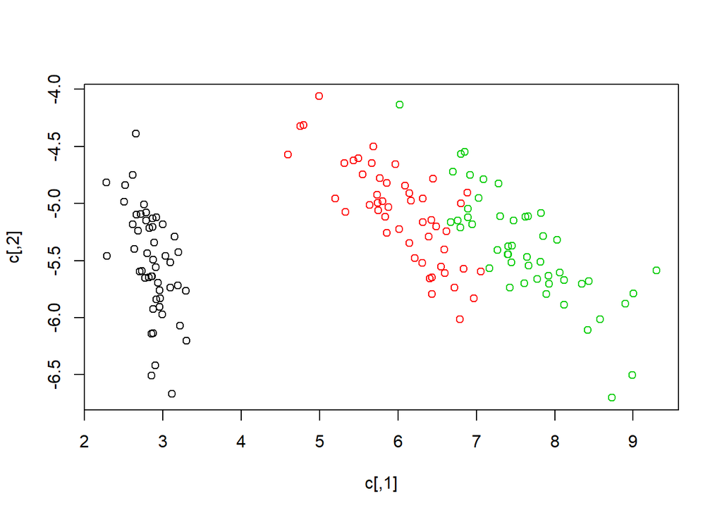

```r
ACP=eigen(V)$vectors
c=as.matrix(iris[,1:4])%*%ACP[,1:2]
plot(c,col=iris$Y)
```

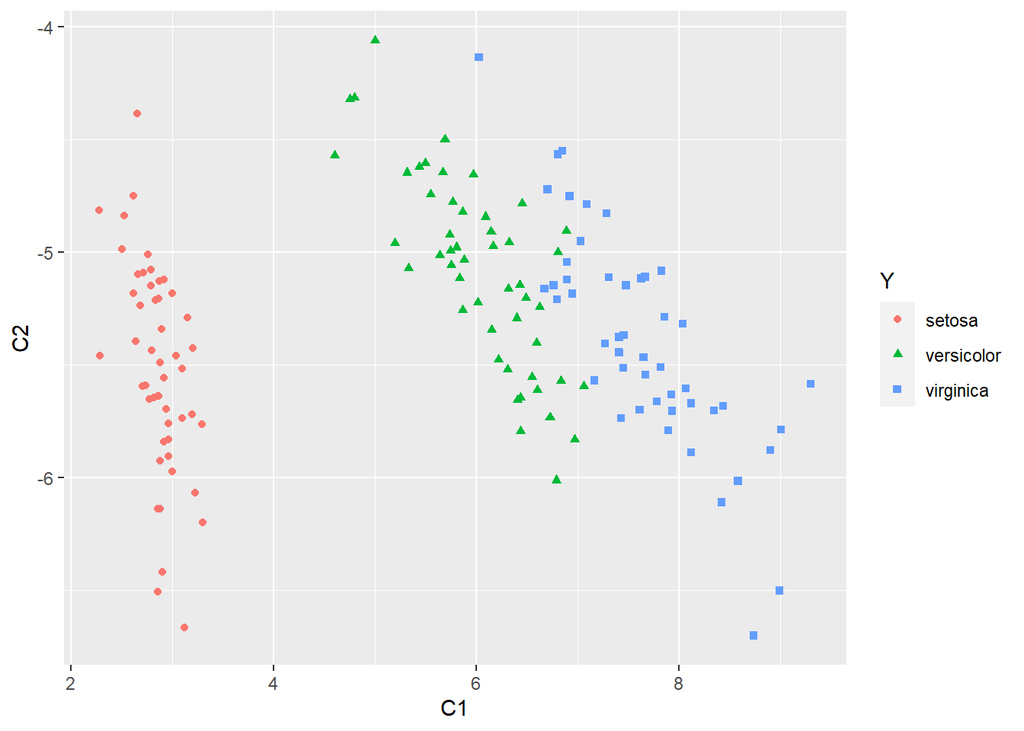

```r
c = as.data.frame(c)
names(c) <- c("C1","C2")
c %>% mutate(Y = iris$Y) %>%
  ggplot(aes(x = C1, y = C2, color = Y, shape = Y)) +
  geom_point()
```

18. Commenter, quel est le pourcentage d’inertie expliqué par chacun des axes ? Pour les deux premiers axes

```r
l = eigen(V)$values
l
```

```
## [1] 4.20005343 0.24105294 0.07768810 0.02367619
```

```r
prop_var = l/sum(l) # 0.924618723 0.053066483 0.017102610 0.005212184
cumsum(prop_var)
```

```
## [1] 0.9246187 0.9776852 0.9947878 1.0000000
```

19. Calculer les coordonnées $d_1$ et $d_2$ des points projetés sur les deux premières composantes discriminantes, sachant qu’en AFD on diagonalise la matrice $V^{-1}B$. Adapter le code pour réaliser l’AFD, et commenter les résultats (on rappelle que l’inverse s’obtient avec la fonction `solve` et le produit matriciel avec l’opérateur `%*%`) :

```r
M = solve(V) %*% B
eigen(M) # Decomposition en valeurs propres
```

```
## eigen() decomposition
## $values
## [1]  9.698722e-01  2.220266e-01  5.441883e-15 -5.292628e-16
##
## $vectors
##            [,1]         [,2]       [,3]       [,4]
## [1,]  0.2087418 -0.006531964  0.2106843 -0.8850525
## [2,]  0.3862037 -0.586610553 -0.3962378  0.2969366
## [3,] -0.5540117  0.252561540 -0.4591404  0.2754433
## [4,] -0.7073504 -0.769453092  0.7666797  0.2294377
```

```r
eigen(M)$values
```

```
## [1]  9.698722e-01  2.220266e-01  5.441883e-15 -5.292628e-16
```

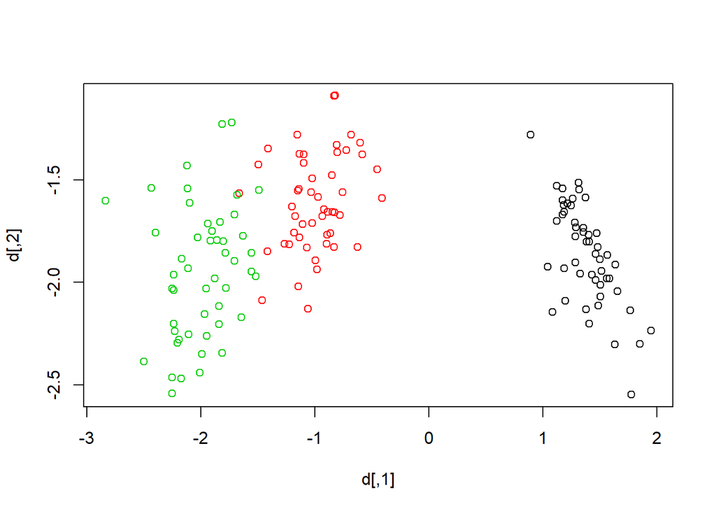

```r
AFD=eigen(M)$vectors
d=as.matrix(iris[,1:4])%*%AFD[,1:2]
plot(d,col=iris$Y)
```

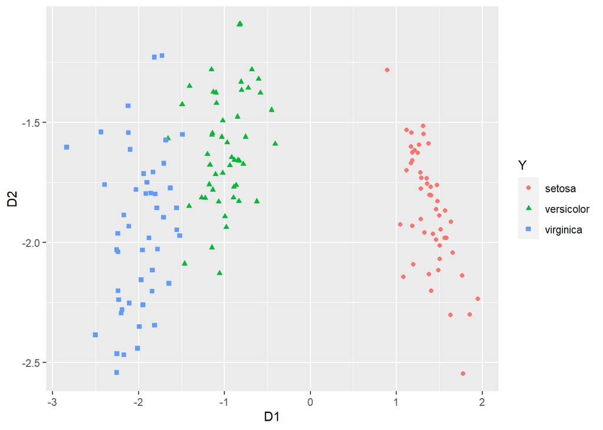

```r
d = as.data.frame(d)
names(d) <- c("D1","D2")
d %>% mutate(Y = iris$Y) %>%
  ggplot(aes(x = D1, y = D2, color = Y, shape = Y)) +
  geom_point()
```

Quels est la part de variance de $d_1$ expliquée par la classe ? De $d_2$

20. Reprendre le code précédent en remplaçant $V^{-1}B$ par $W^{-1}B$.

```r
eigen(solve(V) %*% B)$vectors
```

```
##            [,1]         [,2]       [,3]       [,4]
## [1,]  0.2087418 -0.006531964  0.2106843 -0.8850525
## [2,]  0.3862037 -0.586610553 -0.3962378  0.2969366
## [3,] -0.5540117  0.252561540 -0.4591404  0.2754433
## [4,] -0.7073504 -0.769453092  0.7666797  0.2294377
```

```r
eigen(solve(W) %*% B)$vectors
```

```
##            [,1]         [,2]        [,3]       [,4]
## [1,] -0.2087418 -0.006531964 -0.69871384  0.3910846
## [2,] -0.3862037 -0.586610553  0.02318900 -0.4306213
## [3,]  0.5540117  0.252561540 -0.03791239 -0.4836812
## [4,]  0.7073504 -0.769453092  0.71401953  0.6539653
```

```r
l = eigen(solve(V) %*% B)$values # lambda
eigen(solve(W) %*% B)$values # lambda/(1-lambda)
```

```
## [1]  3.219193e+01  2.853910e-01 -6.565242e-15  4.298805e-15
```

```r
l/(1-l)
```

```
## [1]  3.219193e+01  2.853910e-01  5.441883e-15 -5.292628e-16
```

Que dire ? Quel est le lien entre les différents vecteurs propres et valeurs propres ?

21. Comparer les résultats obtenus à ceux obtenus en ACP.

## Calcul des scores discriminants

On souhaite calculer les fonctions de score pour chacun des groupes, ces fonctions nous serviront ensuite à affecter chaque individu au groupe de plus grand score (équivalent à la minimisation de la distance de Mahalanobis).

On rappelle que le calcul des fonctions de score pour chaque groupe s’effectue comme suit :
$$s_i(x) = \alpha_{i0} + \alpha_{i1}x_1 + \alpha_{i2}x_2 + \alpha_{i3}x_3 + \alpha_{i4}x_4$$
avec $\alpha_{i0} = - \bar{X}_i^T W^{-1} \bar{X}_i$ et
$$\begin{pmatrix} \alpha_{i1} \\ \vdots \\ \alpha_{ip} \end{pmatrix} = 2 W^{-1} \bar{X}_i$$

22. Construire le tableau des coefficients :

|  | Setosa | Versicolor | Virginica |
| --- | --- | --- | --- |
| Constante | $\alpha_{10}$ | $\alpha_{20}$ | $\alpha_{30}$ |
| $X_1$ | $\alpha_{11}$ | $\alpha_{21}$ | $\alpha_{31}$ |
| $X_2$ | $\alpha_{12}$ | $\alpha_{22}$ | $\alpha_{32}$ |
| $X_3$ | $\alpha_{13}$ | $\alpha_{23}$ | $\alpha_{33}$ |
| $X_4$ | $\alpha_{14}$ | $\alpha_{24}$ | $\alpha_{34}$ |

Exemple à la main :

```r
i = 1 # Classe 1 (setosa)
dim(G[i,])
```

[output not shown]

```r
dim(G[i,,drop = FALSE])
```

```
## [1] 1 4
```

```r
Xi <- matrix(G[i,],4,1)
# Xi <- t(G[i,,drop = FALSE])
- t(Xi) %*% solve(W) %*% Xi  # Premier alpha_{i0}
```

```
##           [,1]
## [1,] -173.8977
```

```r
2 * solve(W) %*% Xi # Les 4 autres !
```

```
##         [,1]
## X1  48.04932
## X2  48.13851
## X3 -33.53192
## X4 -35.50696
```

Mise en production !

```r
alpha=matrix(0,5,3)
rownames(alpha) = c("intercept","X1","X2","X3","X4")
colnames(alpha) = levels(iris$Y)
for (i in 1:3) {
  barXi=matrix(G[i,],4,1) # centres de Xj pour Y=i
  alpha[1,i]=-t(barXi)%*%solve(W)%*%barXi
  alpha[2:5,i]=2*solve(W)%*%barXi
}
alpha
```

```
##               setosa versicolor   virginica
## intercept -173.89767 -146.43672 -210.754506
## X1          48.04932   32.03716   25.399692
## X2          48.13851   14.43369    7.520979
## X3         -33.53192   10.63561   26.054173
## X4         -35.50696   13.13108   43.018598
```

Aide : Dans l’AFD, la notion de score est liée au calcul de la règle de décision. Une observation $x = (x_1, x_2, x_3, x_p)$ sera affectée au groupe avec le score $s_i(x)$ maximal.

Rappel :
$$\hat{y} = \arg\min_i (x - \bar{X}_i)^T W^{-1} (x - \bar{X}_i)$$
Ce calcul revient à maximiser $2 x^T W^{-1} \bar{X}_i - \bar{X}_i^T W^{-1}\bar{X}_i$.

23. Calculer les scores des individus à partir de cette règle (simple calcul matriciel, on pourra rajouter une colonne de 1 à la matrice des données à l’aide de la fonction `cbind`)

Exemple à la main pour le calcul des scores

```r
alpha[1,1] + sum(iris[1,1:4] * alpha[2:5,1]) # Score pour l'individu 1 dans la classe 1
```

```
## [1] 185.5926
```

```r
c(1,as.matrix(iris[1,1:4])) %*% alpha[,1, drop = FALSE]
```

```
##        setosa
## [1,] 185.5926
```

```r
c(1,as.matrix(iris[1,1:4])) %*% alpha
```

```
##        setosa versicolor virginica
## [1,] 185.5926    84.9868 -9.813089
```

```r
head(as.matrix(cbind(1,iris[1:4])) %*% alpha)
```

```
##        setosa versicolor  virginica
## [1,] 185.5926   84.98680  -9.813089
## [2,] 151.9135   71.36252 -18.653517
## [3,] 155.2845   66.77827 -24.834677
## [4,] 138.9593   64.25830 -22.915909
## [5,] 185.6015   83.22645 -11.600960
## [6,] 202.1018  106.18833  17.235182
```

Score individu : simple produit matriciel

```r
s=as.matrix(cbind(1,iris[,1:4]))%*%alpha
s[1:10,]
```

```
##         setosa versicolor  virginica
##  [1,] 185.5926   84.98680  -9.813089
##  [2,] 151.9135   71.36252 -18.653517
##  [3,] 155.2845   66.77827 -24.834677
##  [4,] 138.9593   64.25830 -22.915909
##  [5,] 185.6015   83.22645 -11.600960
##  [6,] 202.1018  106.18833  17.235182
##  [7,] 153.2034   68.83796 -18.963173
##  [8,] 172.6206   81.40328 -10.499739
##  [9,] 123.0749   53.90057 -32.105461
## [10,] 156.9248   72.55635 -19.597861
```

```r
names(which.max(s[150,]))
```

```
## [1] "virginica"
```

```r
Ypredit = apply(s, 1, function(x) names(which.max(x)))
```

24. En déduire le classement de chacun des individus à partir de ces scores (en utilisant de façon appropriée les fonctions `apply` et `which.max`) :

On affecte l’individu dans la colonne où le score est le plus élevé :

```r
Ypredit=levels(iris$Y)[apply(s,1,which.max)]
Ypredit[1:10]
```

```
##  [1] "setosa" "setosa" "setosa" "setosa" "setosa" "setosa" "setosa" "setosa"
##  [9] "setosa" "setosa"
```

```r
table(Ypredit)
```

```
## Ypredit
##     setosa versicolor  virginica
##         50         49         51
```

```r
table(Y = iris$Y,Ypredit) # Matrice de confusion
```

```
##             Ypredit
## Y            setosa versicolor virginica
##   setosa         50          0         0
##   versicolor      0         48         2
##   virginica       0          1        49
```

```r
TBC = mean(iris$Y == Ypredit)
TBC
```

```
## [1] 0.98
```

```r
TMC = mean(iris$Y != Ypredit)
TMC
```

```
## [1] 0.02
```